# Allee

Stochastic Gompertz State-Space model with Poisson observation error

José Miguel Ponciano, Orlando Acevedo-Charry, Caroline Poli, Meghan Beatty, Lara Elmquist, & Miguel A. Acevedo

15 July 2025

# 1 Introduction

Here we attempt to answer the question of whether a no-return lower population size threshold can be estimated with the snail kite time series dataset. For every deme, the idea is to fit a discrete-time population dynamics model with an Allee effect. Dennis (2002) showed the following: the deterministic Allee effect population dynamics model with the logistic equation density-dependence contains two equilibria. The first one is an upper equilibrium population size $\tilde{n}_1$, and corresponds to the traditional carrying capacity $K$ of a simple logistic model. That equilibrium is stable, meaning all trajectories starting near it get closer and closer to it over time. A second equilibrium population size $\tilde{n}_2$ that lies in the interval $(0,K)$ exists. That equilibrium is unstable, meaning all trajectories starting near it (either from above or below) diverge from it. The result is that if a population trajectory starts near yet above $\tilde{n}_{2}$ it will grow till reaching $\tilde{n}_1$. However if a population trajectory starts ever so slightly below $\tilde{n}_1$, that population will not grow and will quickly decay and go extinct. Thus, in a very real sense, $\tilde{n}_1$ represents a target population size threshold that must be met for a population to persist. This description is the essence of the deterministic dynamics of a population model with an Allee effect. The biological causes of this dynamics can be many, but the effect still is the same. Scarcity of mates, joint parental control of predators in nesting colonies, optimality of hunting group sizes, heterogeneity in the ability of finding mates and many other processes (see Dennis 1989) all lead to the definition of that lower unstable equilibrium size $\tilde{n}_1$.

When demographic stochasticity (random births and deaths) is included, determinism no longer governs the fate of the population. Dennis (2002) showed that extinction probabilities for a stochastic model with an Allee effect and a carrying capacity can be described as a decreasing function of the current population size with an inflection point. Accordingly, at high initial population sizes the extinction probability is close to zero. This probability then increases seemingly exponentially up until the value of the deterministic unstable equilibrium $\tilde{n}_1$. At that population size the extinction probability curve presents an inflection point and thus dramatically increases as the initial population size becomes smaller and smaller. Hence, $\tilde{n}_1$ marks the population size below which the extinction probability greatly increases and above which it greatly diminishes. If one were to define an extinction threshold based only on population dynamics then estimating $\tilde{n}_1$ seems to be a suitable inference target from time series data. The advantage of targeting an estimate of $\tilde{n}_1$ is that fitting a population dynamics model averages out the effect of a potentially large number of covariates shaping the growth rate and translate these into estimates of model parameters (specifically, the maximum growth rate, the density-dependent parameter, the Allee effect parameter and the amount of environmental variability). The information to estimate these parameters/effects comes from the available length of the time series of population abundances. In what follows, we attempt to estimate and define this lower population extinction threshold by fitting a stochastic Allee effects model to the Snail Kite time series data.

The model with demographic stochasticity and an Allee effect follows the derivation in [Ferguson and Ponciano (2014)](https://onlinelibrary.wiley.com/doi/full/10.1111/ele.12227). Let $X_{i},\,i=1,n_{t}$ be the number of offspring born to individual $i$ given that the current population size at time $t$ is $n_t$. Then the total number of potential recruits for that year is $Y=\sum_{i=1}^{n_{t}}X_{i}$. Letting the offspring distribution $X_{i}$ be iid Poisson distributed with mean $\lambda$ directly gives $Y\sim {\rm Poisson}(\lambda n_{t})$. Typically, the construction of a population dynamics model from this point specifies $\lambda$ as $\lambda = \exp\{a\},$ where $a$ is the maximum growth rate. Under a density independent scenario, $a=$average number of births $-$ average number of deaths. In order to include an Allee effect, we subtract a density-dependent probability of not producing offspring to $a$ (that is, in the scale of the growth rate $R_{t} = {\rm ln}\,n_{t+1}/{\rm ln}\,n_{t}$). [Dennis (1989)](https://onlinelibrary.wiley.com/doi/abs/10.1111/j.1939-7445.1989.tb00119.x) showed that the rectangular hyperbola (RH) form $\frac{n}{n+\theta}$ where $\theta>0$ can be interpreted as the probability of mating that accounts for mating shortage. Then, $1- \frac{n}{n+\theta} = \frac{\theta}{n+\theta}$ is the probability of not mating. Thus, to construct our Allee effects model with demographic stochasticity we set
$$\lambda = {\rm e}^{a-\frac{\psi\theta}{\theta+n}},$$
where $\psi>0$ is a proportionality constant. Next, we let $p(n_{t}) = {\rm e}^{-bn_{t}}$ be the density-dependent survival probability of the potential recruits. Assuming an independent and identical survival process, then *conditional* on the random number of offspring produced $Y$ and a fixed population size $n_{t}$, the total number of recruits surviving for next generation is

$$N_{t+1}|(N_{t}=n_{t},Y) \sim {\rm Binomial}(Y,p(n_{t})).$$
Unconditionally (*i.e.* after averaging over all the possible values of $Y$), it follows that
$$N_{t+1}|(N_{t}=n_{t}) \sim {\rm Poisson}\left(n_{t}{\rm e}^{a-bn_{t} -\frac{\psi\theta}{\theta+n}}\right).$$
This Poisson distribution then defines the transition probabilities from any fixed population size $n_t$ to a new population size $N_{t+1}$. Note that here, the use of capital letters is done according to standard practice in statistics to represent all the possible outcomes of a random variable whereas the lower case letters represent realized, fixed values of a random variable. Parameters are denoted as single roman or greek letters. The above derivation fully defines a Markovian population dynamics process with negative density dependence, an Allee effect and demographic stochasticity.

An alternative model results from adding the effects of environmental stochasticity. To specify a model with both, demographic and environmental stochasticities, we start by redefining $\Lambda_{t} = \exp\{a_{t}\}$, and assuming this quantity varies randomly over time thus embodying environmental stochasticity [Lewontin and Cohen 1969](https://www.pnas.org/doi/abs/10.1073/pnas.62.4.1056). Here, we set $\Lambda_{t}\sim {\rm Gamma}(\alpha,k)$. Then, conditional on the particular year’s realization of the environmental process $\Lambda_t$, the transition probability distribution would be

$$N_{t+1}|(N_{t}=n_{t},\Lambda_{t}) \sim {\rm Poisson}\left(n_{t}\Lambda_{t}{\rm e}^{-bn_{t} -\frac{\psi\theta}{\theta+n}}\right),$$
and averaging out the environmental process over time with this integral
$$Pr(N_{t+1}=n_{t+1}|N_{t}=n_{t}) = \int_{0}^{\infty}\frac{{\rm e}^{-n_{t}\lambda_{t}{\rm e}^{-bn_{t} -\frac{\psi\theta}{\theta+n}}}\left(n_{t}\lambda_{t}{\rm e}^{-bn_{t} -\frac{\psi\theta}{\theta+n}}\right)^{n_{t+1}}}{n_{t+1}!}\frac{\alpha^{k}}{\Gamma(k)}\lambda_{t}^{k-1}{\rm e}^{-\alpha\lambda_{t}} d\lambda_{t}$$
immediately gives the following Negative Binomial transition probability distribution that incorporates the effects of both, demographic and environmental stochasticities:
$$Pr(N_{t+1}=n_{t+1}|N_{t}=n_{t}) =\frac{\Gamma(n_{t+1}+k)}{\Gamma(k)n_{t+1}!}{\rm P}^{k}{\rm Q}^{n_{t+1}},\,\text{where}$$
${\rm P} + {\rm Q} = 1,\,{\rm P} = \frac{\alpha}{g(n_{t})+\alpha}$ and $g(n_{t}) = {\rm e}^{-bn_{t} -\frac{\psi\theta}{\theta+n_{t}}}$.

Before delving into the parameter estimation process, note that the expected value for both stochastic models of population dynamics is exactly equal to the deterministic Ricker model with added Allee effects:

$$n_{t+1} = f(n_{t}) =\lambda n_{t} g(n_{t}) = n_{t}{\rm e}^{a-bn_{t} -\frac{\psi\theta}{\theta+n_{t}}}.$$
An equilibrium for this deterministic model is by definition given by the population size $n^{*}$ that satisfies
$$n^{*} = f(n^{*}) = n^{*}{\rm e}^{a-bn^{*} -\frac{\psi\theta}{\theta+n^{*}}},$$
or equivalently, by the value $n^*$ that makes the growth rate $R_t$ equal to zero, *i.e.*:
$$a-bn^{*} -\frac{\psi\theta}{\theta+n^{*}} = 0.$$
Solving the above equation for the equilibrium immediately gives two solutions:
$$n^{*}_{1,2} = \frac{(a-b\theta) \pm \sqrt{a^{2} + 2ab\theta + b^{2}\theta^{2} -4b\psi\theta}}{2b}.$$
Of these two solutions, the one for which the specific parameter values gives $\left|f'(n^{*}) \right|<1$ is the stable equilibrium and the one for which $\left|f'(n^{*}) \right|\geq 1$ is the unstable Allee effect equilibrium [Kot 2001](https://www.cambridge.org/core/books/elements-of-mathematical-ecology/6F91A5D3AB89EECE130825ED5529B8DE). For this model an explicit expression of the derivative of the model map can be written:
$$f'(n) = {\rm e}^{a-bn-\frac{\psi\theta}{(\theta +n)}}\left(1 - nb + \frac{n\psi\theta}{(\theta +n)^{2}} \right).$$
Evaluating this derivative on the equilibria gives
$$f'(n^{*}) = \left(1 - n^{*}b + \frac{n^{*}\psi\theta}{(\theta +n^{*})^{2}} \right).$$
Alright, once the deterministic model has been examined, the unstable equilibrium found and given that we have the transition probability distributions for two versions of a stochastic population dynamics model, we are ready to estimate the model parameters. Here as before, the logical thing to do is expand this single population model to the multiple demes scenario and add an extra migration term to the model. Before doing so, I present a few simulations to visualize the behavior of the model at the unstable equilibrium and the estimation of the Allee effect model for the aggregated population counts using JAGS.

```r
# Function to simulate from Poisson-Ricker model
Allee.Ricker.Sim <- function(a,b,psi,theta,no,len){

    # Note:  b>0 because I have a '-' here:exp(a-b*nim1)
    popvec <- rep(0,len)
    popvec[1] <- no
    for(i in 2:len){
        nim1  <- popvec[(i-1)]
        mean.pois <- nim1*exp(a-b*nim1 - psi*theta/(nim1+theta))
        popvec[i] <- mean.pois
    }
    return(popvec)
}
a <- 0.88
b <- 0.003#0.002
psi <- 1.1#seq(0.5,0.8,by=0.01)
theta <- 60

real.sol.test <- ((a^2 + 2*a*b*theta + (b^2)*(theta^2))/(4*b*theta)) > psi
print(real.sol.test)
```

```
## [1] TRUE
```

```r
n1.star <- ((a-b*theta) + sqrt(a^2 + 2*a*b*theta + (b^2)*(theta^2)-4*b*psi*theta))/(2*b)
n2.star <- ((a-b*theta) - sqrt(a^2 + 2*a*b*theta + (b^2)*(theta^2)-4*b*psi*theta))/(2*b)
print(n1.star)
```

```
## [1] 212.6412
```

```r
print(n2.star)
```

```
## [1] 20.69213
```

```r
f.prime.nstar1 <- 1-n1.star*b + (n1.star*psi*theta)/((theta+n1.star)^2)
f.prime.nstar2 <- 1-n2.star*b + (n2.star*psi*theta)/((theta+n2.star)^2)

print(abs(f.prime.nstar1)) # <1 so stable equilibrium
```

```
## [1] 0.5508792
```

```r
print(abs(f.prime.nstar2)) # >1 so unstable equilibrium
```

```
## [1] 1.147666
```

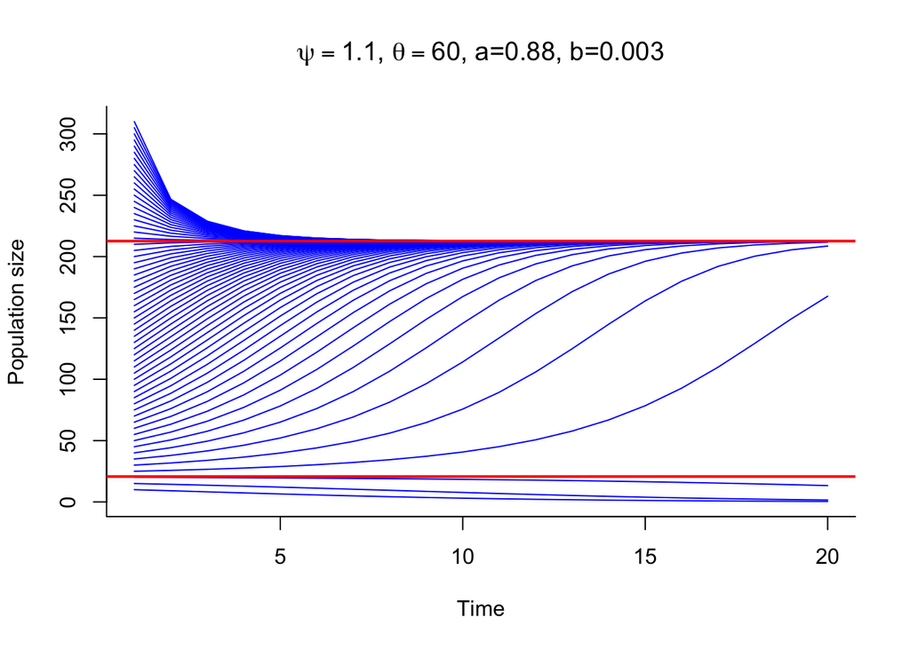

```r
len <- 20
novec <- seq(from=floor(n2.star)-10, to= floor(n1.star)+100, by=5)
ntrajs <- length(novec)
trajmat <- matrix(0,nrow=ntrajs, ncol=len)
for(i in 1:ntrajs){

  trajmat[i,] <- Allee.Ricker.Sim(a=a,b=b,psi=psi,theta=theta,no=novec[i], len=len)

}
par(mfrow=c(1,1))
for(i in 1:ntrajs){

  if(i==1){plot(1:len,trajmat[i,],type="l", lwd=1, col="blue",
                xlab="Time", ylab="Population size", bty="l",
                ylim=range(trajmat),
                main=expression(paste(psi==1.1,", ",theta==60,", a=0.88", ", b=0.003")))
                }else{
          points(1:len,trajmat[i,],type="l", lwd=1, col="blue")
        }
}
abline(h=n1.star, lwd=2, col="red")
abline(h=n2.star, lwd=2, col="red")
```

OK, now we write down a stochastic population dynamics model simulator and compute the probability of extinction when the initial population size changes from low to high, between 0 and $n_{1}^{*}$ passing through $n_{2}^{*}$

```r
Allee.SRicker.Sim <- function(k,alpha,b,psi,theta,no,len){

    # Note:  b>0 because I have a '-' here:exp(a-b*nim1)
    popvec <- rep(0,len)
    popvec[1] <- no
    for(i in 2:len){
        nim1  <- popvec[(i-1)]
        Lam <- rgamma(n=1,shape=k,rate=alpha)
        mean.pois <- Lam*nim1*exp(-b*nim1 - psi*theta/(nim1+theta))
        popvec[i] <- rpois(n=1,lambda=mean.pois)
    }
    return(popvec)
}

# Selecting gamma parameter values so that shape/rate = exp(a)
E.gamma <- exp(a)

#Set the shape parameter to 6
shape.p <- 6
rate.p  <- shape.p/E.gamma
rate.p
```

```
## [1] 2.488697
```

```r
shape.p/(rate.p^2)
```

```
## [1] 0.9687396
```

```r
novec <- seq(from=floor(n2.star), to= floor(n1.star)+80, by=5)
novec <- c(seq(1,(novec[1]-1),by=5),novec)
ntrajs <- length(novec)
```

Now we do the simulations tracking progress for good measure

```r
Nsims <- 100000 # number of simulations to estimate P(extinct) for each "no"
len <- 30

library(progress) # For progress bar
trajoutcome <- matrix(0,nrow=Nsims, ncol=ntrajs)

pb <- progress_bar$new(total=ntrajs)
for(i in 1:ntrajs){

  pb$tick() #new progress bar tick
  Sys.sleep(1/ntrajs)

  for(j in 1:Nsims){

    ijsim <- Allee.SRicker.Sim(k=shape.p, alpha=rate.p,b=b,psi=psi,theta=theta,no=novec[i], len=len)
    trajoutcome[j,i] <- ijsim[len] == 0

  }

}

ext.probs <- apply(trajoutcome,2,function(x){sum(x)/length(x)})
#length(ext.probs)
#length(50:90)

saveRDS(ext.probs, "Code/ext.probs.RDS")
```

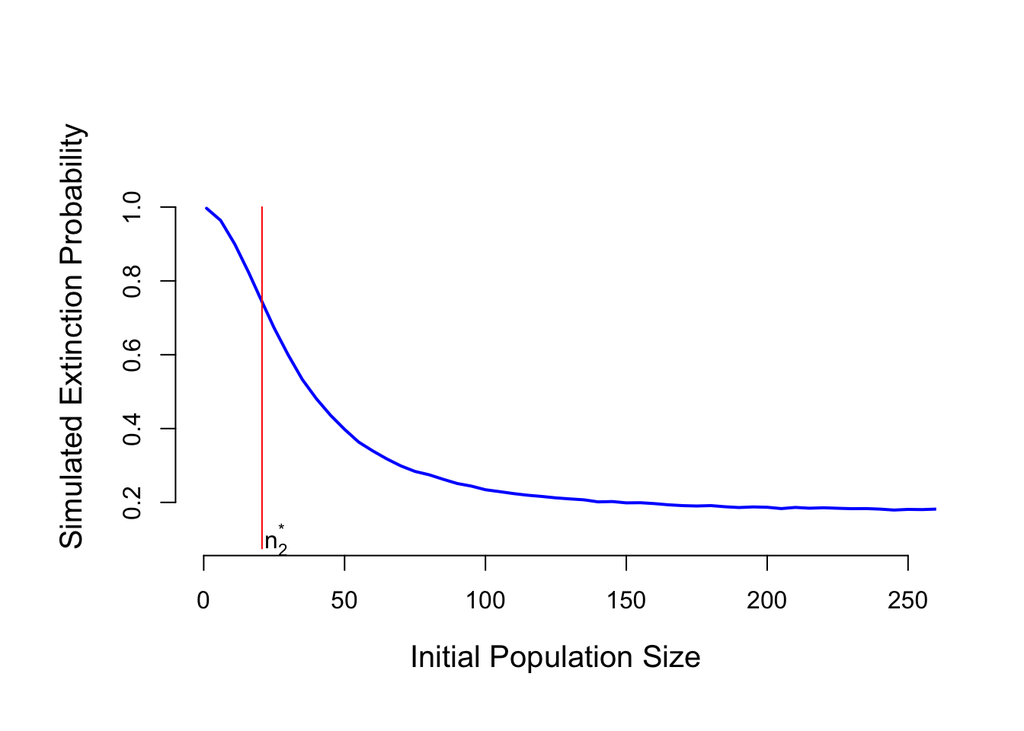

```r
ext.probs <- readRDS("Code/ext.probs.RDS")
par(mfrow=c(1,1), oma=c(1,1,1,1), mar=c(5,5,3,2))
plot(novec,ext.probs, type="l", lwd=2,col="blue",
     bty="l",xlim=c(0,250), ylim=c(0.1,1.2),
     xlab="Initial Population Size", ylab="Simulated Extinction Probability",
     axes=FALSE, cex.lab=1.25)
axis(side=1, at=seq(0,250,by=50))
axis(side=2, at=seq(0.2,1.0,by=0.2))
points(rep(n2.star,2), c(0.075,1), type="l", col="red")
text(n2.star+5,0.10, expression(n[2]^"*"))
```

First, let’s load the packages in `R` needed to run this code

```r
# R functions and datasets to support "Modern Applied Statistics with S",
  #a book from W.N. Venables and B.D. Ripley
library(MASS);
# R functions for Data Cloning (maximum likelihood estimation using Bayesian MCMC)
library(dclone);
# Create plots for MCMC output
library(mcmcplots)
# Data manipulation and elegant figures
library(tidyverse)
# Palettes inspired by works at the Metropolitan Museum of Art in New York
library(MetBrewer)
```

First we read the data

```r
rawdat <- read.csv("Code/snailkite counts 1997_2025.csv")
head(rawdat, 12) # first 12 rows
```

|  | X | year | survey_num | EAST | EVER | KRV | OKEE | PP | SJM | OTHER |
| --- | --- | --- | --- | --- | --- | --- | --- | --- | --- | --- |
| 1 | 1 | 1997 | 1 | 3 | 123 | 36 | 28 | NA | 47 | NA |
| 2 | 2 | 1997 | 2 | 2 | 67 | 19 | 20 | NA | 33 | NA |
| 3 | 3 | 1997 | 3 | 5 | 118 | 30 | 22 | NA | 26 | NA |
| 4 | 4 | 1997 | 4 | 3 | 106 | 27 | 32 | NA | 34 | NA |
| 5 | 5 | 1997 | 5 | 14 | 240 | 36 | 88 | NA | 29 | NA |
| 6 | 6 | 1997 | 6 | 7 | 131 | 28 | 33 | NA | 32 | NA |
| 7 | 7 | 1998 | 1 | 12 | 127 | 3 | 19 | NA | 16 | NA |
| 8 | 8 | 1998 | 2 | 0 | 226 | 17 | NA | NA | 22 | NA |
| 9 | 9 | 1998 | 3 | 5 | 168 | 20 | 59 | NA | 17 | NA |
| 10 | 10 | 1998 | 4 | 5 | 229 | 11 | 28 | NA | 46 | NA |

[output cut: 2 more lines]

```r
tail(rawdat, 12) # last 12 rows
```

|  | X | year | survey_num | EAST | EVER | KRV | OKEE | PP | SJM | OTHER |
| --- | --- | --- | --- | --- | --- | --- | --- | --- | --- | --- |
| 163 | 163 | 2024 | 1 | 2 | 0 | 214 | 222 | 2 | 64 | 12 |
| 164 | 164 | 2024 | 2 | 7 | 0 | 224 | 294 | NA | 55 | 15 |
| 165 | 165 | 2024 | 3 | 8 | 0 | 156 | 295 | 0 | 50 | 25 |
| 166 | 166 | 2024 | 4 | NA | 0 | 161 | 291 | NA | 40 | NA |
| 167 | 167 | 2024 | 5 | NA | 0 | 173 | 180 | NA | 56 | 18 |
| 168 | 168 | 2024 | 6 | 36 | 0 | 114 | 107 | NA | 27 | 31 |
| 169 | 169 | 2025 | 1 | 22 | 0 | 37 | 62 | NA | 56 | 7 |
| 170 | 170 | 2025 | 2 | 32 | 0 | 23 | 28 | NA | NA | 36 |
| 171 | 171 | 2025 | 3 | NA | NA | NA | NA | NA | NA | 2 |
| 172 | 172 | 2025 | 4 | NA | NA | NA | NA | NA | NA | NA |

[output cut: 2 more lines]

We can extract information from this dataset to be organized according to the modeling requirements:

```r
names.rawdat <- names(rawdat)
deme.names <- c("EAST","EVER","KRV","OKEE","PP","SJM","OTHER" )
cols.with.counts <- match(deme.names, names.rawdat)

years <- unique(rawdat$year)
nyears <- length(years)
year.col <- which(names.rawdat=="year",arr.in=TRUE)
```

We are using a simple time scale from 0 to 28 `tt`, but we can use the ‘years’ vector above to do the plots.

```r
tt <- years - years[1]
```

We can also organize the number of surveys

```r
# List the survey numbers:
surv.num <- unique(rawdat$survey_num)
```

We can save the reorganized data in a list of three matrices, one per survey (Surveys 4, 5, and 6 are `S4mat`, `S5mat`, and `S6mat`, respectively). We can also extract the NA presence in a list of three matrices (`NAS.list <- list(NA4mat = S4mat, NA5mat=S5mat, NA6mat=S6mat)`).

```r
S4mat <- S5mat <- S6mat <- matrix(0, nrow=7, ncol=nyears)

Counts.list <- list(S4mat = S4mat, S5mat=S5mat, S6mat=S6mat)
NAS.list  <- list(NA4mat = S4mat, NA5mat=S5mat, NA6mat=S6mat)
short.inds.list <- list()
```

And finally, we can iterativelly for each of the three surveys (`i in 1:3`) fill the matrices in the empty lists. First we will use the survey number to locate our survey of interest (`surv.num[(i+3)]`). Then, we ask the row number of the surveys within the `rawdat` dataset. We extract the rows for each survey in each region or subpopulation, and transpose this subset `t()`. The columns of this transposed subset correspond to the time series vector `tt` (because is only one of the surveys), so from 0 to 28 (29 years). This matrix is saved in `Counts.lists`. Then we identify the years with NA for each supbopulation, and save them in `NAS.list`. Finally, for each population (6 + “OTHER”), we save the counts with NAs.

```r
for(i in 1:3){

  SN <- surv.num[(i+3)]

  ith.rows   <- which(rawdat$survey_num==SN, arr.ind=TRUE)

  #ith.datmat <- rawdat[ith.rows, c(year.col,cols.with.counts)]
  ith.datmat <- t(rawdat[ith.rows, cols.with.counts])
  colnames(ith.datmat) <- tt

  Counts.list[[i]] <- ith.datmat

  ith.isnamat <- 1-is.na(ith.datmat)
  NAS.list[[i]] <- ith.isnamat

  ith.shortind.list <- list()
  for(j in 1:7){

    ith.shortind.list[[j]] <- which(ith.isnamat[j,]==1,arr.ind=TRUE)

  }
  names(ith.shortind.list) <- deme.names
  short.inds.list[[i]] <- ith.shortind.list

}
names(short.inds.list) <- c("short.inds4","short.inds5", "short.inds6")
```

Now create the individual data matrices with the surveys for 28 years

```r
S4mat <- Counts.list$S4mat[1:6,1:28] # Cut the last time step: no data anywhere
S5mat <- Counts.list$S5mat[1:6,1:28]
S6mat <- Counts.list$S6mat[1:6,1:28]

NA4mat <- NAS.list$NA4mat[1:6,1:28]
NA5mat <- NAS.list$NA5mat[1:6,1:28]
NA6mat <- NAS.list$NA6mat[1:6,1:28]
```

Now, we can bring the distance between regions, using the centroid and distance from the edge of a convex polygon of the historical geolocation of nests in each region. The data was provided in meters, but it could be convenient numerically to convert it to kilometers. In addition, we assign the row names that matches with our survey matrices.

```r
# mean distance from the centroid
centr.dists <- read.csv("Code/Demes_centroid distance in meters.csv")[,-1]
centr.dists <- as.matrix(centr.dists)/1000
rownames(centr.dists) <- rownames(S4mat)
centr.dists
```

```
##         EAST    EVER     KRV    OKEE      PP     SJM
## EAST   0.000 107.136 140.929  53.358 346.350  90.316
## EVER 107.136   0.000 209.721  98.977 421.761 185.599
## KRV  140.929 209.721   0.000 112.526 212.353  70.586
## OKEE  53.358  98.977 112.526   0.000 324.806  90.723
## PP   346.350 421.761 212.353 324.806   0.000 258.350
## SJM   90.316 185.599  70.586  90.723 258.350   0.000
```

```r
# minimal distance between edges of the convex polygon of nests
min.condists <- read.csv("Code/Demes_minimum distance in meters.csv")[,-1]
min.condists <- as.matrix(min.condists)/1000
rownames(min.condists) <- rownames(S4mat)
min.condists
```

```
##         EAST    EVER     KRV    OKEE      PP     SJM
## EAST   0.000  13.771  43.385  15.924 298.085  35.273
## EVER  13.771   0.000  95.826  20.378 369.028 112.259
## KRV   43.385  95.826   0.000  25.243 163.055  23.540
## OKEE  15.924  20.378  25.243   0.000 297.987  48.160
## PP   298.085 369.028 163.055 297.987   0.000 241.972
## SJM   35.273 112.259  23.540  48.160 241.972   0.000
```

The number of (sub)populations `p` is defined next. This number will appear in most of our overall demes calculations

```r
p <- nrow(S4mat)
```

We next define the “dinvmat” choosing one of the distance matrices. This is the inverse matrix of distances, because in our model, the effect of one region on the growth rate of another region will be made inversely proportional to their mutual geographical distance.

```r
dmat <- centr.dists
dinvmat <- (dmat/dmat^2)
diag(dinvmat) <- rep(0,p)
dinvmat
```

```
##             EAST        EVER         KRV        OKEE          PP         SJM
## EAST 0.000000000 0.009333931 0.007095772 0.018741332 0.002887253 0.011072235
## EVER 0.009333931 0.000000000 0.004768240 0.010103357 0.002371011 0.005387960
## KRV  0.007095772 0.004768240 0.000000000 0.008886835 0.004709140 0.014167115
## OKEE 0.018741332 0.010103357 0.008886835 0.000000000 0.003078761 0.011022563
## PP   0.002887253 0.002371011 0.004709140 0.003078761 0.000000000 0.003870718
## SJM  0.011072235 0.005387960 0.014167115 0.011022563 0.003870718 0.000000000
```

Finally, we import the matrix of detectability estimates over the years:

```r
detectabilities <- read.csv("Code/detectability.csv")

phats <- detectabilities[-(1:4),1]
```

## 1.1 Model and data cloning ML fit:

We now write down the JAGS model to fit the Allee effects model above:

```r
Allee.SRicker.Sim <- function(k,alpha,b,psi,theta,no,len){
    # Note:  b>0 because I have a '-' here:exp(a-b*nim1)
    popvec <- rep(0,len)
    popvec[1] <- no
    for(i in 2:len){
        nim1  <- popvec[(i-1)]
        Lam <- rgamma(n=1,shape=k,rate=alpha)
        mean.pois <- Lam*nim1*exp(-b*nim1 - psi*theta/(nim1+theta))
        popvec[i] <- rpois(n=1,lambda=mean.pois)
    }
    return(popvec)
}


SRAMOD.ONEDEME <- function(){

  lk ~ dnorm(2,1.6)
  k <- exp(lk)
  lalpha ~ dnorm(1,1.6)
  alpha <- exp(lalpha)

  lb ~ dnorm(-5.8, 1.6)
  b <- exp(b)

  psi ~ dunif(0,1)
  theta ~ dunif(0,80)

  # dgamma(r=k,lambda=alpha)

}
```